# Assessing injury on GOM cetaceans

# 1 Preamble

This is an Electronic Supplement to the manuscript Marques et al. “Quantifying Deepwater Horizon oil spill induced injury on pelagic cetaceans” submitted to Marine Ecology Progress Series (MEPS).

There are 8 Electronic Supplements to the paper. The master file containing links to all the other 7 additional Electronic Supplements related to this paper is ES0_ElectronicSupplements.

You might be reading this file as a pdf or as an html. The links on this file only work if you are using the html version of it, available via the github repository or if you compiled it yourself as html and you have all the 8 html files in the same folder. Otherwise, as a pdf distributed as an Electronic Supplement to the MEPS paper, the links might not work. *They might work. If it is possible, we can work with the MEPS Editorial Office such that we can add links below that will link to actual files, say the pdfs of each of these 8 files, on the publisher server*.

## 1.1 Version history

This section details the version history for static pdf files submitted as Electronic Supplement pdfs:

- 1.0 [12 Aug 2022] Version included as a pdf Electronic Supplement in the MEPS original submission
- 2.0 [10 Feb 2023] Version included as a pdf Electronic Supplement in the MEPS re-submission after 1st round of reviewer’s comments

# 2 Introduction

In this document we present the results of the age, sex and class structured model implemented for all species/stock in the GOM.

We report here the injury metrics originally considered in Schwacke et al. (2017): (1) lost cetacean years (LCY), the difference between the baseline and injured population sizes, summed over the entire modeled time period; (2) years to recovery (YTR), the number of years required before the injured population trajectory reaches 95% of the baseline population trajectory; and (3) maximum proportional decrease (MPD), the difference between the two population trajectories when the injured trajectory is at its lowest point, divided by the baseline. Note that LCY is intuitively the metric that is most dependent on initial population size.

# 3 Running the simulations

The code below runs the simulations for all species, and stores the results in appropriate files, stored in appropriate species specific folders.

This code is included for completeness and does not need to be run as part of compiling this dynamic report as the results are already available in relevant files and it takes a considerably log time to run.

Creating objects to hold summary results:

The taxonomic units and the corresponding codes considered in this document are:

- Bwsp - beaked whales, Beaked whales spp
- Fatt - pygmy killer whale, *Feresa attenuata*
- Ggri - Risso’s dolphin, *Grampus griseus*
- Gmac - short-finned pilot whale, *Globicephala macrorhynchus*
- Kosp - Kogia species, *Kogia* sp.
- Pele - melon-headed whale, *Peponocephala electra*
- Pmac - sperm whale, *Physeter macrocephalus*
- Satt - pantropical spotted dolphin, *Stenella attenuata*
- Sbre - rough-toothed dolphin, *Steno bredanensis*
- Scly - Clymene dolphin, *Stenella clymene*
- Scoe - striped dolphin, *Stenella coeruleoalba*
- Sfro - Atlantic spotted dolphin, *Stenella frontalis*
- Slon - spinner dolphin, *Stenella longirostris*
- Ttro - offshore bottlenose dolphins, *Tursiops truncatus*
- Ttrs - shelf bottlenose dolphins, *Tursiops truncatus*

We re-order the results tables upfront so that results are organized by alphabetical order of the 4 letter code used to describe the taxonomic unit (this is also the order that the species are reported in tables 1 to 3 of the offshore paper).

The data for initial population sizes and proportion exposed are imported from a `txt` file produced inside ES2_ElectronicSupplements.

# 4 Results by species

We represent in turn, for each species, the simulated population trajectories under the oil spill and under the baseline scenarios, as well as the histograms of the distributions of the 3 injury metrics for each species. To each histogram four dashed vertical lines were added:

- green - median value for the injury metric
- black - mean value for the injury metric
- blue - 95% confidence interval for the injury metric

## 4.1 *Physeter macrocephalus* (Pmac, sperm whale)

Population trajectories

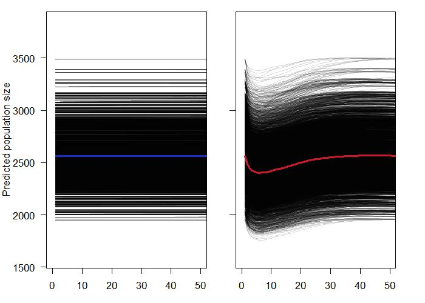

Mean for each of the injury metrics

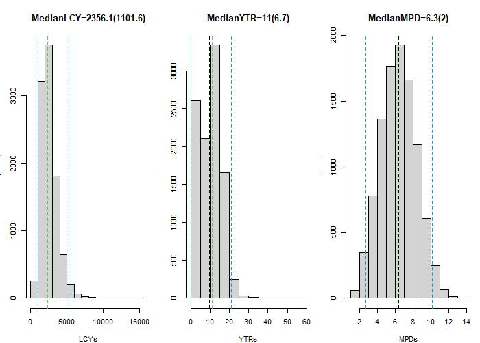

```
##         LCY         YTR         MPD
## 2549.139215    9.725500    6.375102
```

## 4.2 *Kogia* sp. (Kosp, kogia)

Population trajectories

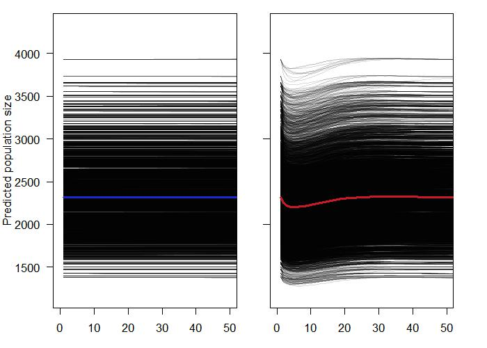

Mean for each of the injury metrics

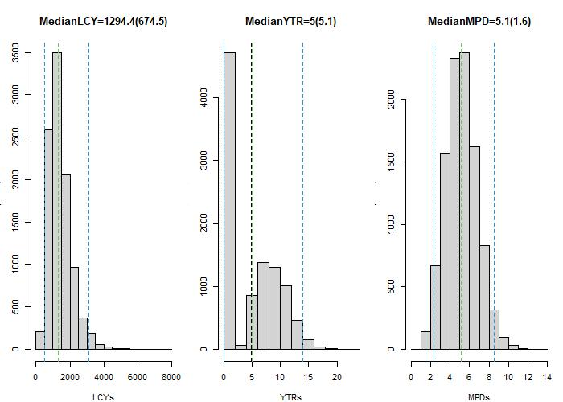

```
##         LCY         YTR         MPD
## 1429.418506    4.898900    5.185119
```

## 4.3 *Stenella clymene* (Scly, Clymene dolphin)

Population trajectories

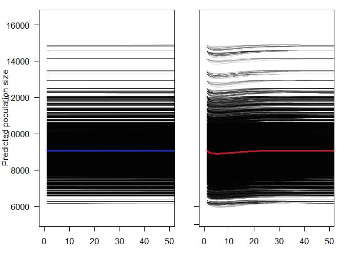

Mean for each of the injury metrics

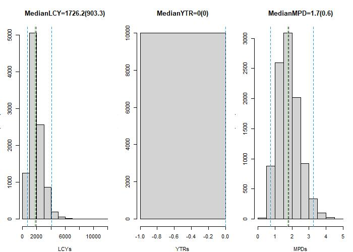

```
##         LCY         YTR         MPD
## 1901.525708    0.000000    1.801292
```

## 4.4 *Peponocephala electra* (Pele, melon-headed whale)

Population trajectories

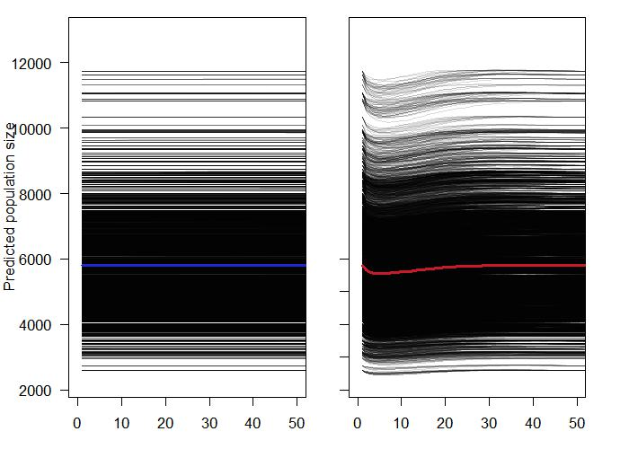

Mean for each of the injury metrics

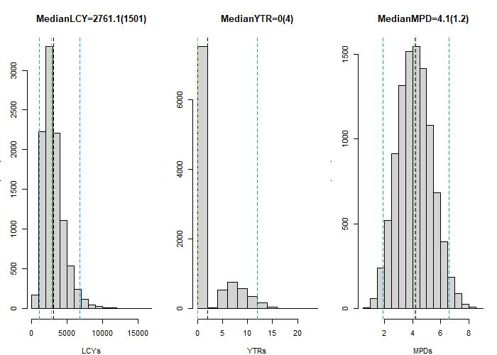

```
##         LCY         YTR         MPD
## 3071.523882    2.137900    4.168256
```

## 4.5 *Tursiops truncatus* (Ttro, offshore bottlenose dolphin)

Population trajectories

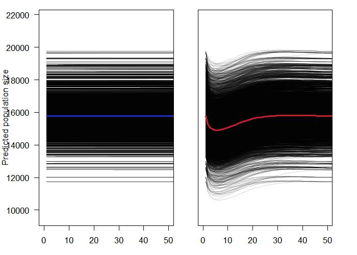

Mean for each of the injury metrics

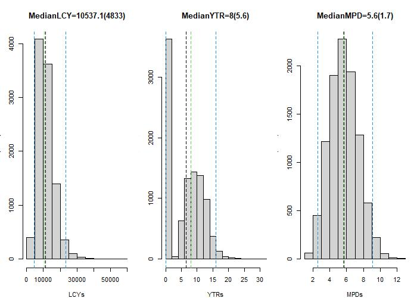

```
##          LCY          YTR          MPD
## 11369.564397     6.586900     5.658282
```

## 4.6 *Globicephala macrorhynchus* (Gmac, short finned pilot whale)

Population trajectories

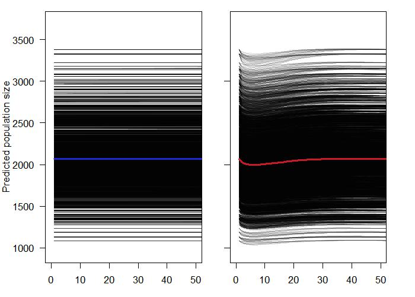

Mean for each of the injury metrics

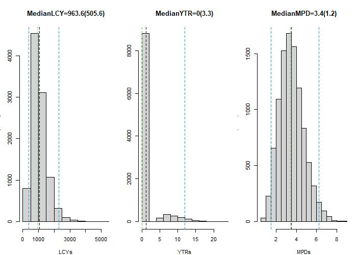

```
##         LCY         YTR         MPD
## 1057.863912    1.156400    3.538044
```

## 4.7 *Feresa attenuata* (Fatt, pygmy killer whale)

Population trajectories

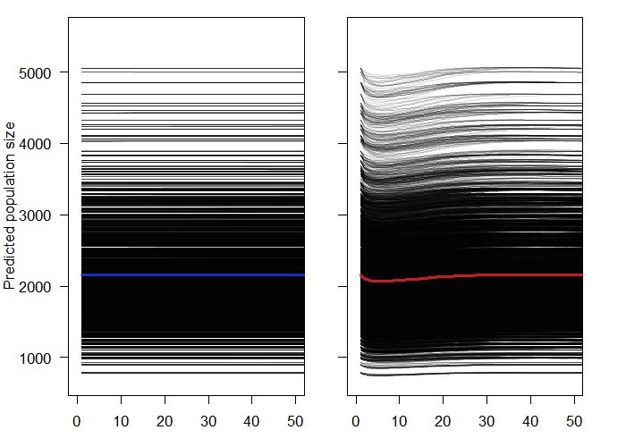

Mean for each of the injury metrics

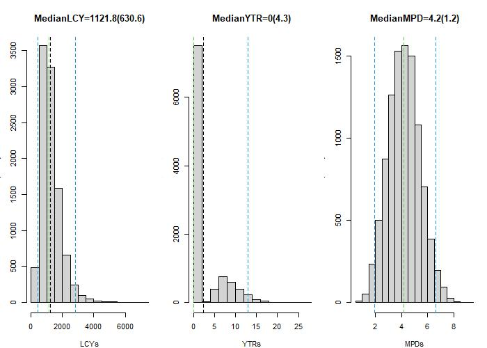

```
##         LCY         YTR         MPD
## 1249.503621    2.308200    4.194471
```

## 4.8 *Grampus griseus* (Ggri, Risso’s dolphin)

Population trajectories

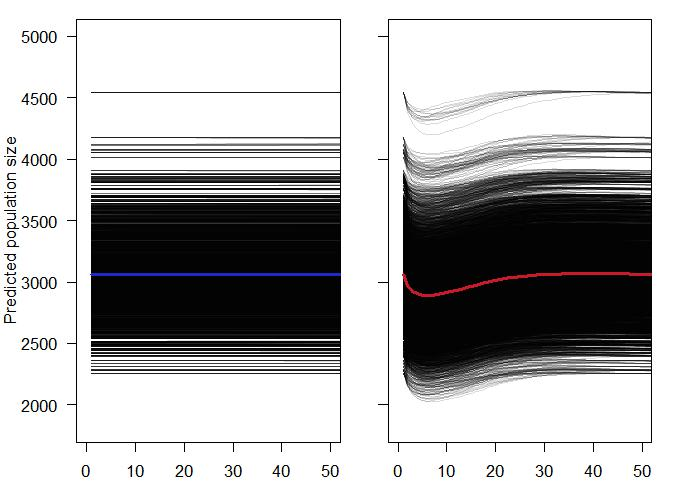

Mean for each of the injury metrics

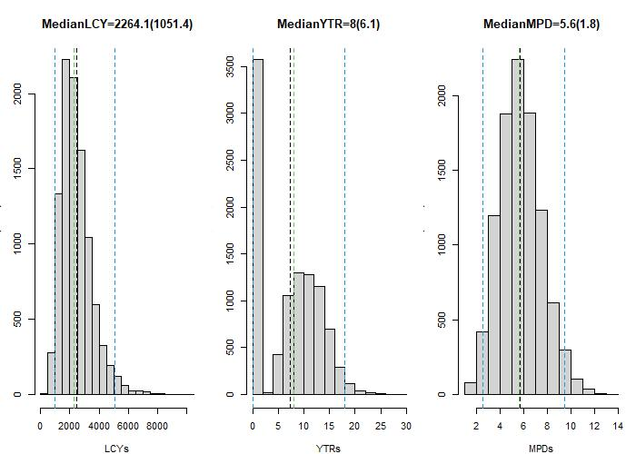

```
##         LCY         YTR         MPD
## 2449.136975    7.290900    5.735186
```

## 4.9 *Steno bredanensis* (Sbre, rough-toothed dolphin)

Population trajectories

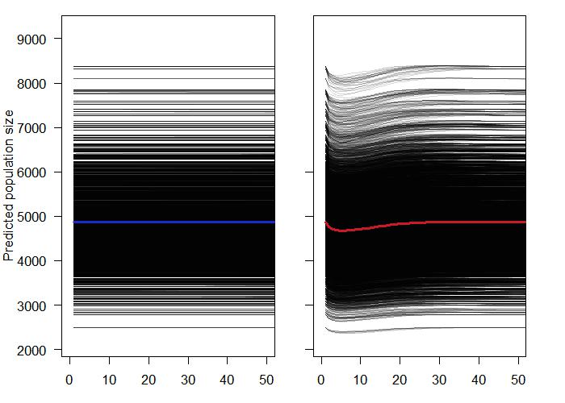

Mean for each of the injury metrics

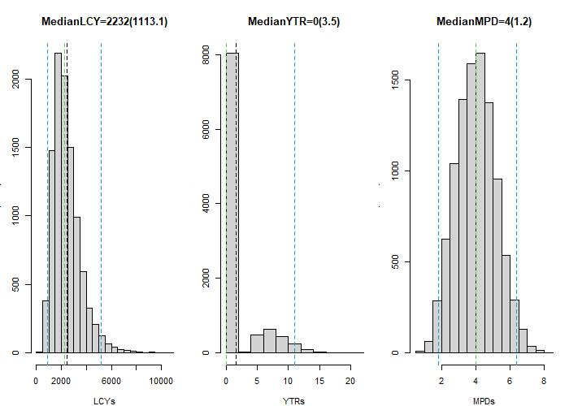

```
##         LCY         YTR         MPD
## 2434.417513    1.640900    4.006926
```

## 4.10 *Stenella attenuata* (Satt, pantropical spotted dolphin)

Population trajectories

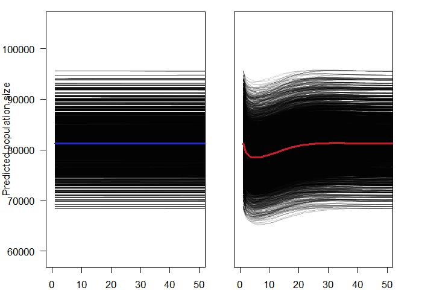

Mean for each of the injury metrics

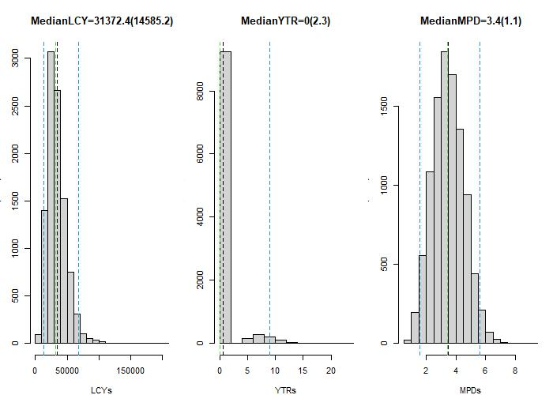

```
##          LCY          YTR          MPD
## 33809.632317     0.635700     3.474522
```

## 4.11 *Tursiops truncatus* (Ttrs, shelf bottlenose dolphin)

Population trajectories

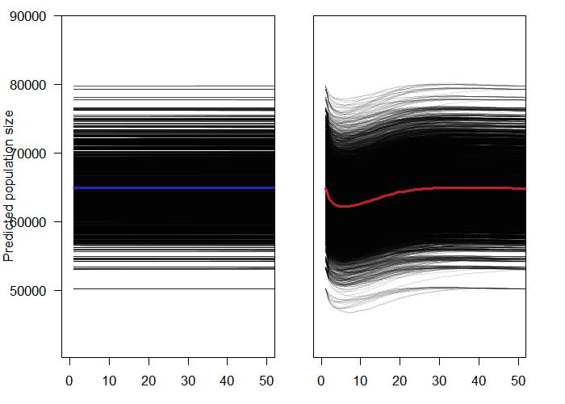

Mean for each of the injury metrics

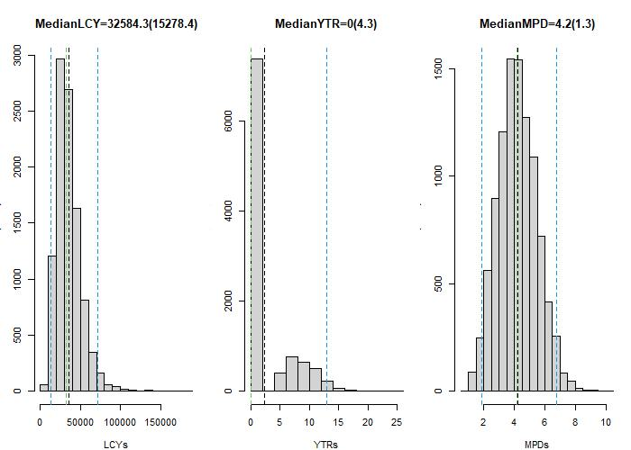

```
##          LCY          YTR          MPD
## 35190.477524     2.435900     4.191836
```

## 4.12 *Stenella longirostris* (Slon, spinner dolphin)

Population trajectories

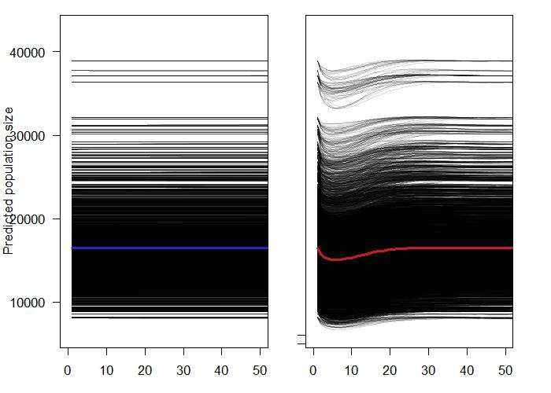

Mean for each of the injury metrics

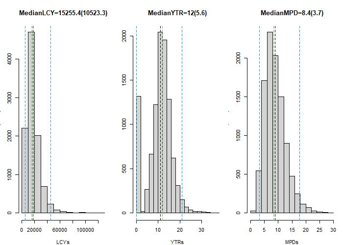

```
##          LCY          YTR          MPD
## 17714.767745    11.196700     8.899829
```

## 4.13 *Stenella coeruleoalba* (Scoe, striped dolphin)

Population trajectories

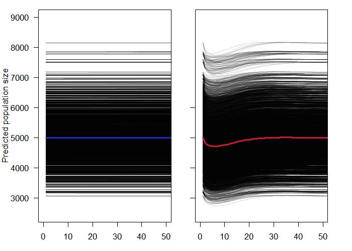

Mean for each of the injury metrics

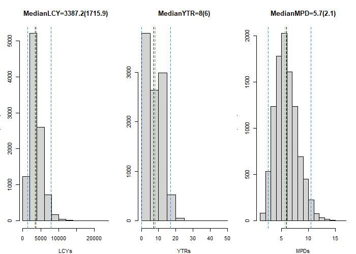

```
##         LCY         YTR         MPD
## 3715.207476    7.108100    5.883191
```

## 4.14 *Stenella frontalis* (Sfro, Atlantic spotted dolphin)

Population trajectories

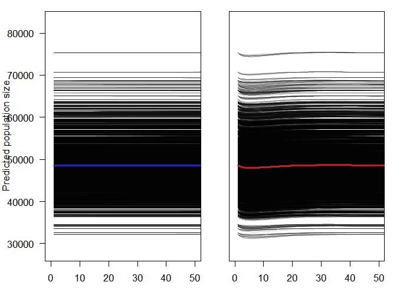

Mean for each of the injury metrics

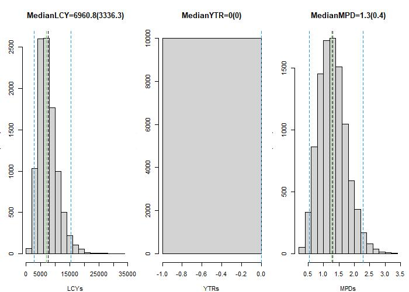

```
##         LCY         YTR         MPD
## 7509.270139    0.000000    1.296869
```

## 4.15 Beaked whales spp (Bwsp)

Population trajectories

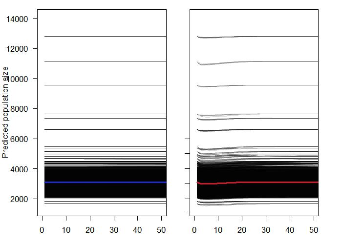

Mean for each of the injury metrics

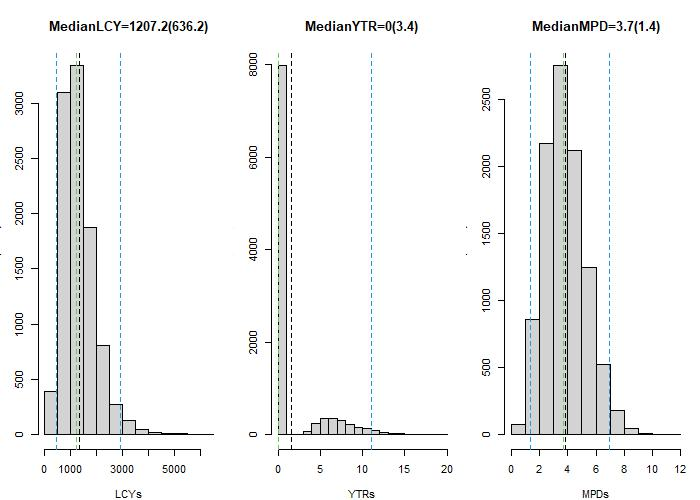

```
##         LCY         YTR         MPD
## 1320.899319    1.592200    3.816632
```

# 5 Comparisons across species

In this section we present some summary analysis of the results across the 15 taxonomic units considered.

## 5.1 Initial population and proportion exposed

The population size and the proportion exposed are $a priori$ expected to be key determinants of injury, since the population size will have a direct impact on LCY and the proportion exposed should have a direct impact on all 3 measures.

Initial population size (N) and proportion exposed (Pexp) for the different stocks considered.

| Sp | Nstart | Pexp |
| --- | --- | --- |
| Bwsp | 3098 | 0.140 |
| Fatt | 2152 | 0.145 |
| Ggri | 3063 | 0.197 |
| Gmac | 2065 | 0.120 |
| Kosp | 2322 | 0.197 |
| Pele | 5784 | 0.152 |
| Pmac | 2561 | 0.191 |
| Satt | 81233 | 0.155 |
| Sbre | 4867 | 0.148 |
| Scly | 9065 | 0.082 |
| Scoe | 5011 | 0.247 |
| Sfro | 48688 | 0.058 |
| Slon | 16501 | 0.377 |
| Ttro | 15791 | 0.206 |
| Ttrs | 64897 | 0.177 |

The proportion exposed against the initial population size is shown here for the 15 taxonomic units

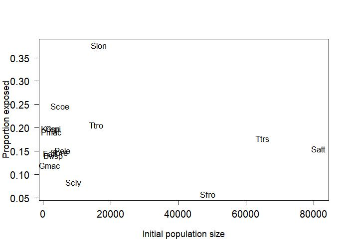